# Basic expression data visualization

Siobhan Cusack

2025-02-14

## Structuring your expression data

Whether you have gene or protein expression data, you’ll need to get it formatted properly for ggplotting. As an example of how your data might be structured, here is a gene expression dataset that I [downloaded from GEO](https://www.ncbi.nlm.nih.gov/geo/query/acc.cgi?acc=GSE256167) (#GSE256167):

```r
setwd("C:/Users/G02.047/Documents/R_Workshop/Expression_data")
df = read.delim("data/GSE256167_read_counts.csv", sep = ",", header = 1)
df[1:10,]
```

```
##        Name gene locus_tag X24h.amp.rep.1 X24h.amp.rep.2 X24h.amp.rep.3
## 1   zwf CDS  zwf     b1852          251.0          350.0          400.0
## 2   zur CDS  zur     b4046           54.5           92.5           59.0
## 3  zupT CDS zupT     b3040          118.0          202.5          132.5
## 4  zraS CDS zraS     b4003           90.5          334.0          258.5
## 5  zraR CDS zraR     b4004          237.5          483.5          334.5
## 6  zraP CDS zraP     b4002           23.0           59.0           72.5
## 7  znuC CDS znuC     b1858          152.5          147.5          192.5
## 8  znuB CDS znuB     b1859          167.5          200.5          227.0
## 9  znuA CDS znuA     b1857          350.0          332.0          374.5
## 10 zntR CDS zntR     b3292          136.5          100.0           92.5
##    X6h.cip.rep.1 X6h.cip.rep.2 X6h.cip.rep.3
## 1         1241.0           836        1026.0
## 2          116.5            51          83.0
## 3          510.5           344         315.5
## 4           73.0            34          68.5
## 5          412.0           293         402.5
## 6            3.5             6           8.5
## 7          141.0           123         159.5
## 8          215.0           123         250.5
## 9          534.5           514         514.5
## 10          55.0            37          59.0
```

The dataset shows the name of each transcript, the gene associated with it, the locus tag, and expression values for three replicates each of samples treated with ampicillin or ciprofloxacin. This dataframe broke one of the basic rules of not angering R: starting a column name with a number. It therefore added the letter X before each of the column names containing the actual datapoints. Because the timepoints are not actually relevant in this case (they vary only with antibiotic), we will rename these columns to include only the name of the antibiotic and the replicate number.

```r
colnames(df) = c("Name", "gene", "locus_tag", "ampicillin_rep1", "ampicillin_rep2", "ampicillin_rep3", "ciprofloxacin_rep1", "ciprofloxacin_rep2", "ciprofloxacin_rep3")
df[1:10,]
```

```
##        Name gene locus_tag ampicillin_rep1 ampicillin_rep2 ampicillin_rep3
## 1   zwf CDS  zwf     b1852           251.0           350.0           400.0
## 2   zur CDS  zur     b4046            54.5            92.5            59.0
## 3  zupT CDS zupT     b3040           118.0           202.5           132.5
## 4  zraS CDS zraS     b4003            90.5           334.0           258.5
## 5  zraR CDS zraR     b4004           237.5           483.5           334.5
## 6  zraP CDS zraP     b4002            23.0            59.0            72.5
## 7  znuC CDS znuC     b1858           152.5           147.5           192.5
## 8  znuB CDS znuB     b1859           167.5           200.5           227.0
## 9  znuA CDS znuA     b1857           350.0           332.0           374.5
## 10 zntR CDS zntR     b3292           136.5           100.0            92.5
##    ciprofloxacin_rep1 ciprofloxacin_rep2 ciprofloxacin_rep3
## 1              1241.0                836             1026.0
## 2               116.5                 51               83.0
## 3               510.5                344              315.5
## 4                73.0                 34               68.5
## 5               412.0                293              402.5
## 6                 3.5                  6                8.5
## 7               141.0                123              159.5
## 8               215.0                123              250.5
## 9               534.5                514              514.5
## 10               55.0                 37               59.0
```

And we don’t currently need the “Name” or “locus_tag” fields so we can drop those:

```r
df = subset(df, select = -c(Name,locus_tag))
df
```

```
##         gene ampicillin_rep1 ampicillin_rep2 ampicillin_rep3 ciprofloxacin_rep1
## 1        zwf          251.00          350.00          400.00            1241.00
## 2        zur           54.50           92.50           59.00             116.50
## 3       zupT          118.00          202.50          132.50             510.50
## 4       zraS           90.50          334.00          258.50              73.00
## 5       zraR          237.50          483.50          334.50             412.00
## 6       zraP           23.00           59.00           72.50               3.50
## 7       znuC          152.50          147.50          192.50             141.00
## 8       znuB          167.50          200.50          227.00             215.00
## 9       znuA          350.00          332.00          374.50             534.50
## 10      zntR          136.50          100.00           92.50              55.00
## 11      zntB          129.00          240.00          179.00             404.00
## 12      zntA          257.50          680.00          462.50             483.00
## 13      zitB          123.50          135.00          134.00             157.00
## 14      zipA          579.50          581.00          747.00            2128.50
```

[output cut: 8705 more lines]

And now we will use `tidyr` magic to combine columns 2 through 7 into three columns: one with the antibiotic name, one with the replicate number, and one with the expression value. To do this, we call the function `pivot_longer`, specifying the data (`data = df`), the columns to transform (`cols = 2:7`), the names of the columns that information currently in the headers should occupy in the output dataframe (`names_to = c("Treatment", "Replicate")`), the character used to divide the sections of the header (`names_sep = "_"`), and the name of the column that the actual expression values will be in (`values_to = "Expression"`).

```r
library(tidyr)

d2 = pivot_longer(data = df, cols = 2:7, names_to = c("Treatment", "Replicate"), names_sep = "_", values_to = "Expression")
d2[1:10,]
```

```
## # A tibble: 10 × 4
##    gene  Treatment     Replicate Expression
##    <chr> <chr>         <chr>          <dbl>
##  1 zwf   ampicillin    rep1           251
##  2 zwf   ampicillin    rep2           350
##  3 zwf   ampicillin    rep3           400
##  4 zwf   ciprofloxacin rep1          1241
##  5 zwf   ciprofloxacin rep2           836
##  6 zwf   ciprofloxacin rep3          1026
##  7 zur   ampicillin    rep1            54.5
##  8 zur   ampicillin    rep2            92.5
##  9 zur   ampicillin    rep3            59
## 10 zur   ciprofloxacin rep1           116.
```

Now that we have a tidied dataframe, we can proceed with visualizing the data.

## Heatmaps

In the previous section on basic graphing we covered ways to visualize gene expression for a few genes. But what if you have thousands? A heatmap is more suited to this task. Here, we will group the data on the x-axis by treatment group and replicate and on the y-axis by gene name, showing the expression value with variations in color.

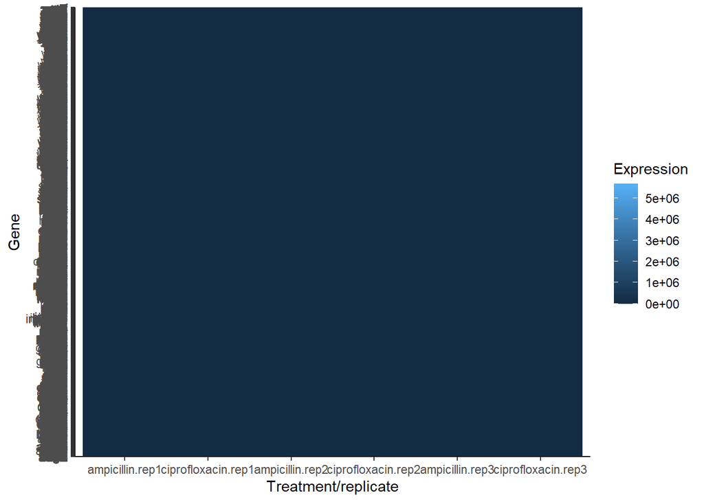

```r
library(ggplot2)

ggplot(data = d2, aes(x = interaction(Treatment, Replicate), y = gene, fill = Expression)) +
geom_tile() +
theme_classic() +
labs(x = "Treatment/replicate", y = "Gene")
```

There are many problems with this graph: - The x-axis labels are overlapping because they are not angled - The y-axis labels are overlapping because there are too many - The data points cannot be distinguished from each other at all

The first two problems are more or less aesthetic, but the last one is not. To solve this, we will apply a log transformation to the expression values.

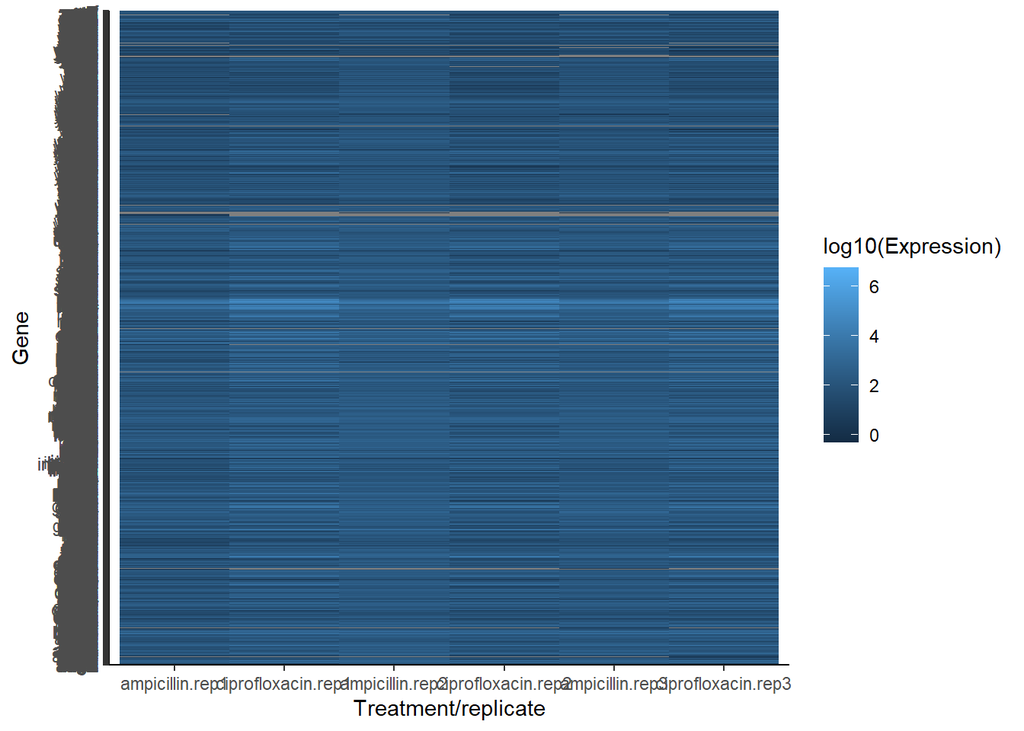

```r
ggplot(data = d2, aes(x = interaction(Treatment, Replicate), y = gene, fill = log10(Expression))) +
geom_tile() +
theme_classic() +
labs(x = "Treatment/replicate", y = "Gene")
```

We’ll graph it again, this time angling the x-axis labels and using the log-transformed values.

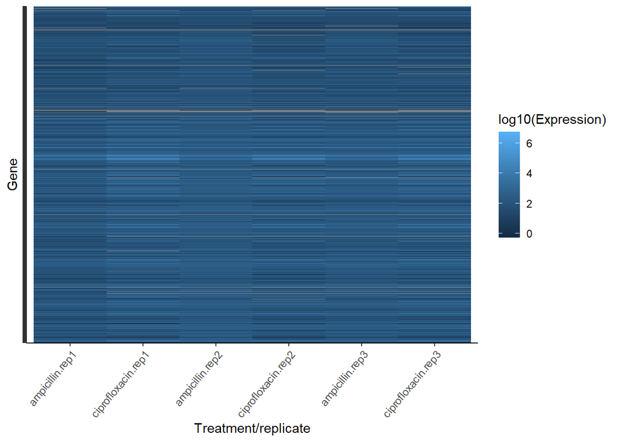

```r
ggplot(data = d2, aes(x = interaction(Treatment, Replicate), y = gene, fill = log10(Expression))) +
geom_tile() +
theme_classic() +
labs(x = "Treatment/replicate", y = "Gene") +
theme(axis.text.x = element_text(angle = 50, hjust = 1)) +
theme(axis.text.y = element_blank())
```

Finally, we could use faceting to separate the antibiotics from each other to more clearly show differences between the treatment groups; here, we will remove the treatment/replicate interaction term as the x-axis variable and replace it with replicate to avoid having empty columns in each facet:

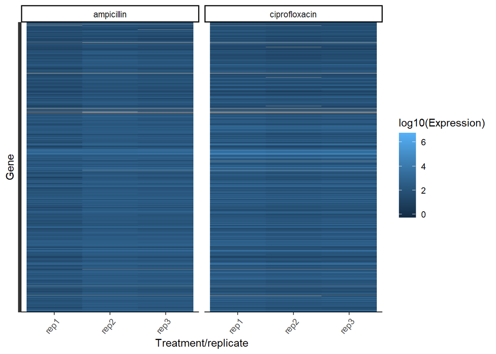

```r
ggplot(data = d2, aes(x = Replicate, y = gene, fill = log10(Expression))) +
geom_tile() +
theme_classic() +
labs(x = "Treatment/replicate", y = "Gene") +
theme(axis.text.x = element_text(angle = 50, hjust = 1)) +
theme(axis.text.y = element_blank()) +
facet_wrap(~Treatment)
```

In a later section we will discuss setting the order of variables on an axis. This is helpful if you want to, for example, make this graph prettier by showing the genes in order of expression in one of the samples. This type of graph is most useful for demonstrating overall patterns of differential expression, of which there are few in this dataset. For a more detailed view of expression patterns across conditions for specific genes, you would need to use a much smaller dataset so you could actually see the gene labels.

There are a lot of other things you might want to do with a heatmap in this context, like generating and displaying gene expression clusters, but unfortunately these are beyond the scope of this workshop. There are resources available that show you how to cluster your data and integrate them into heatmaps (like [this one](https://bioinformatics.ccr.cancer.gov/docs/data-visualization-with-r/Lesson5_intro_to_ggplot/)), but they may not be ggplot-based.

## Volcano plots

If you have processed expression data and you wish to visualize differentially expressed genes or proteins, the most common way is with a volcano plot. One of our colleagues recently generated some gene expression data like this using stressed and control *E. coli* and generously donated some processed data. Please note that I have randomized the gene names and expression values to protect their identities, so these results probably don’t make sense biologically as displayed here. First we’ll look at the structure of the processed dataset. The expression values were calculated as the log2 fold change in the stressed compared to control sample; these values and the adjusted *p*-values are what we need.

```r
setwd("C:/Users/G02.047/Documents/R_Workshop/Expression_data")
rel = read.delim("data/relative_gene_expression.csv", sep = ",", header = 1)
rel
```

```
##        Gene     baseMean log2FoldChange     lfcSE          stat       pvalue
## 1      aaeR 3.471439e+02   -0.192653406 0.4451210  -0.432813553 6.651502e-01
## 2       aas 3.494150e+03   -0.130824444 0.4107317  -0.318515978 7.500936e-01
## 3       aat 1.115960e+04   -0.059527708 0.3887366  -0.153131299 8.782947e-01
## 4      abpA 7.803394e+00   -3.648322550 0.9898076  -3.411698780 6.455940e-04
## 5      abpB 5.345503e+01   -1.201104486 0.5513829  -2.178069529 2.940086e-02
## 6      accA 3.798147e+02   -0.313344497 0.4460024  -0.702579710 4.823177e-01
## 7      accB 1.618689e+01   -0.392259430 0.6896002  -0.569595796 5.689519e-01
## 8      accC 1.426813e+01   -0.384581940 0.6457759  -0.596056768 5.511373e-01
## 9      accD 2.627045e+01   -1.069890502 0.5921713  -1.807183717 7.073364e-02
## 10     aceA 3.933807e+01    0.227198655 0.5157215   0.440601584 6.595015e-01
## 11     aceB 5.645747e+00   -0.340511081 0.9109518  -0.375471063 7.073102e-01
## 12     aceE 1.139290e+01   -0.360330932 0.7021104  -0.513699386 6.074622e-01
## 13     aceF 2.431030e+01   -1.821349845 0.5949933  -3.056790451 2.237206e-03
## 14     aceK 2.648856e+01   -0.288228802 0.5560380  -0.518570998 6.040599e-01
```

[output cut: 5623 more lines]

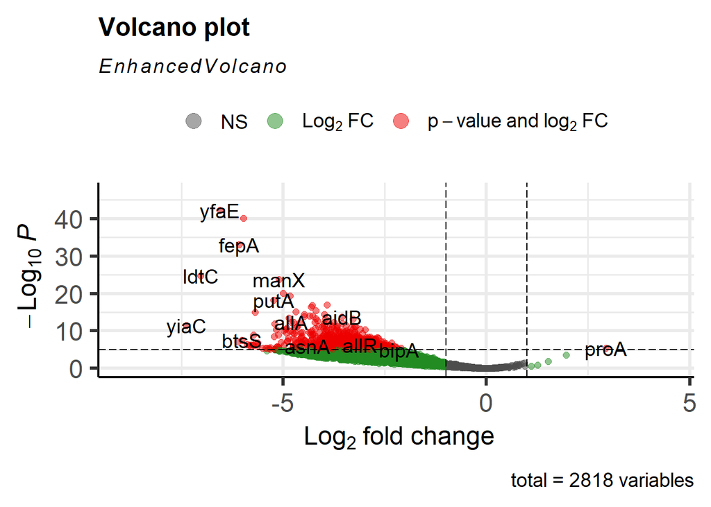

```r
library(EnhancedVolcano)
EnhancedVolcano(toptable = rel, x = "log2FoldChange", y = "padj", lab = rel$Gene)
```

There are a lot of options for changing your EnhancedVolcano plot according to your needs; see their documentation [here](https://bioconductor.org/packages/devel/bioc/vignettes/EnhancedVolcano/inst/doc/EnhancedVolcano.html#advanced-features) to learn more.

## Functional enrichment

Once you’ve identified genes that are significantly up- or down-regulated, you can use a variety of methods to assess functional enrichment. This is usually done for annotations such as Gene Ontology (GO) or Kyoto Encyclopedia of Genes and Genomes (KEGG) terms. I use the website [FUNAGE-Pro](http://funagepro.molgenrug.nl/) because it’s very easy to use and automatically incorporates many functional annotation types, including GO, KEGG, PFAM, eggNOG, and others. I recently did this type of analysis with Bibakhya using data from control and stressed bacteria and I will show you how I generated some of the graphs that she ended up using. These are fictional data inspired by her dataset, so please don’t bother trying to find biological meaning here. Below are significantly enriched GO terms among genes that were upregulated our imaginary bacteria in response to stress:

```r
setwd("C:/Users/G02.047/Documents/R_Workshop/Expression_data")
go = read.delim("data/enriched_GO_terms_example.txt", sep = "\t", header = 1)
go
```

```
##      ClassID Class            Function Class_representation  Pvalue
## 1 GO:0016049    GO     cellular growth             27.40000 4.1e-04
## 2 GO:0009408    GO    response to heat             14.28571 1.5e-05
## 3 GO:0006935    GO          chemotaxis             66.66667 5.7e-06
## 4 GO:0016020    GO            membrane             28.57143 5.0e-04
## 5 GO:0032993    GO protein-DNA complex            100.00000 0.0e+00
## 6 GO:0005524    GO         ATP binding             20.97297 5.5e-05
## 7 GO:0016301    GO     kinase activity             33.33333 4.5e-05
## 8 GO:0003677    GO         DNA binding             50.00000 7.0e-04
##               Domain
## 1 Biological Process
## 2 Biological Process
## 3 Biological Process
## 4 Cellular Component
## 5 Cellular Component
## 6 Molecular Function
## 7 Molecular Function
## 8 Molecular Function
```

Here, class representation indicates the percentage of genes in your group that have the indicated annotation out of the total number of genes in the organism that have that annotation. We’d like to visualize the class representation, the *p*-value, and the domain for each annotation. Thus, we have four variables: two continuous and two categorical. Starting with just the class representation for each function, we will display this as a bar chart:

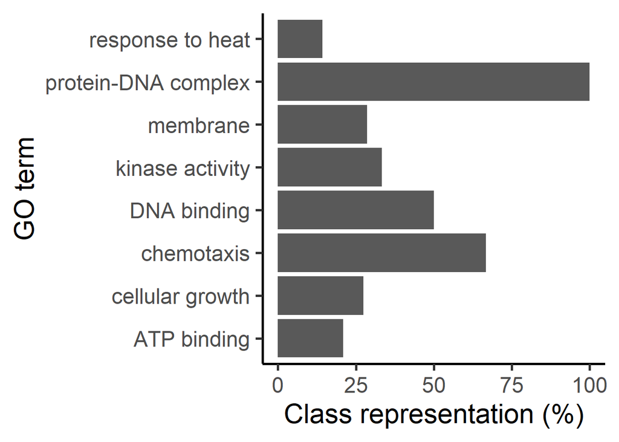

```r
library(ggplot2)

ggplot(data = go, aes(x = Class_representation, y = Function)) +
geom_bar(stat = "identity") +
theme_classic(base_size = 22) +
labs(x = "Class representation (%)", y = "GO term")
```

To incorporate the domain information, we will color-code each bar by domain.

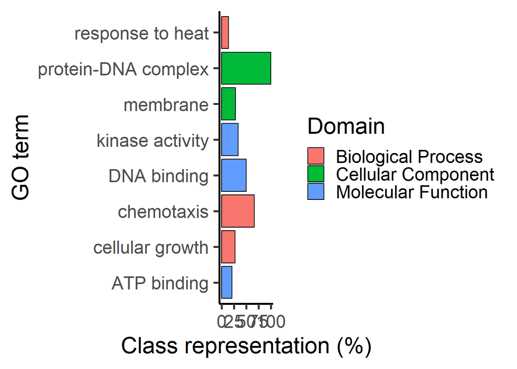

```r
ggplot(data = go, aes(x = Class_representation, y = Function, fill = Domain)) +
geom_bar(stat = "identity", color = "black") +
theme_classic(base_size = 22) +
labs(x = "Class representation (%)", y = "GO term")
```

Finally, to include the *p*-values, we will have the saturation of each bar correspond to this variable.

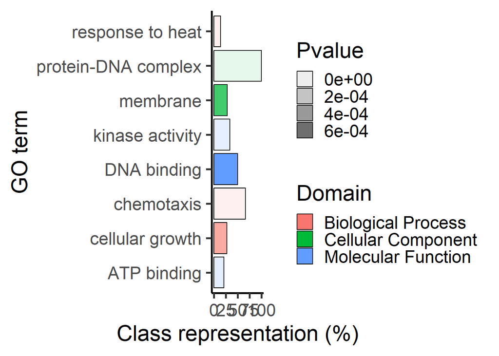

```r
ggplot(data = go, aes(x = Class_representation, y = Function, fill = Domain, alpha = Pvalue)) +
geom_bar(stat = "identity", color = "black") +
theme_classic(base_size = 22) +
labs(x = "Class representation (%)", y = "GO term")
```

To tidy this up a little bit, we can group the GO terms by domain and by class representation:

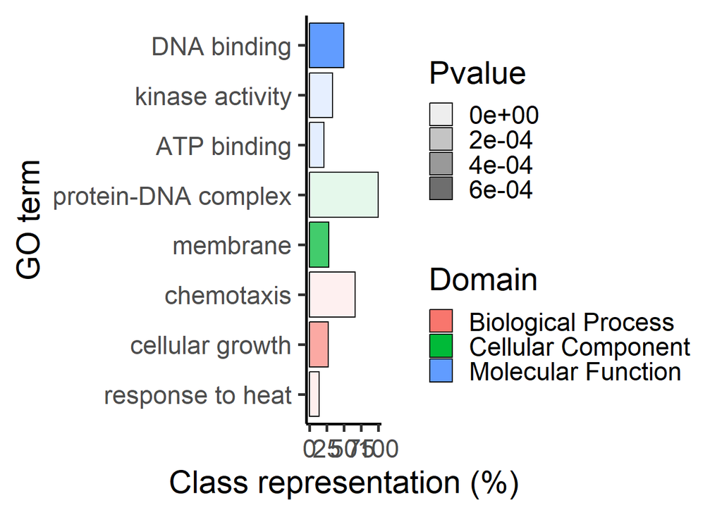

```r
go2 = go[with(go, order(Domain, Class_representation)), ]
go$Function = factor(go$Function, levels = go2$Function)
ggplot(data = go, aes(x = Class_representation, y = Function, fill = Domain, alpha = Pvalue)) +
geom_bar(stat = "identity", color = "black") +
theme_classic(base_size = 22) +
labs(x = "Class representation (%)", y = "GO term")
```

For the same imaginary bacteria, let’s say we also have KEGG terms that are significantly upregulated and downregulated during stress:

```r
setwd("C:/Users/G02.047/Documents/R_Workshop/Expression_data")
kegg = read.delim("data/KEGG_up_down.txt", sep = "\t", header = 1)
kegg
```

```
##                       ClassID Class Description Class_representation pvalue
## 1  Oxidative phosphorylation   KEGG     ko00190             60.00000 0.0270
## 2  Glycolysis/gluconeogenesis  KEGG     ko00010             55.55556 0.0350
## 3         Pyruvate metabolism  KEGG     ko00620             40.90909 0.0440
## 4       Tryptophan metabolism  KEGG     ko00380             37.50000 0.0310
## 5              Motor proteins  KEGG     ko04814             56.60377 0.0026
## 6     Fatty acid biosynthesis  KEGG     ko00061             59.09091 0.0430
## 7              Quorum sensing  KEGG     ko02024             61.11111 0.0430
## 8               Cell adhesion  KEGG     ko04514             64.28571 0.0430
## 9              RNA polymerase  KEGG     ko03020            100.00000 0.0000
## 10          Biofilm formation  KEGG     ko02026            100.00000 0.0000
##         direction
## 1  downregulation
## 2  downregulation
## 3  downregulation
## 4  downregulation
## 5    upregulation
## 6    upregulation
## 7    upregulation
## 8    upregulation
## 9    upregulation
## 10   upregulation
```

A nice way to display these would be to make a bar chart with the Class ID on the y-axis, class representation on the x-axis, and the direction of differential regulation indicated by the color.

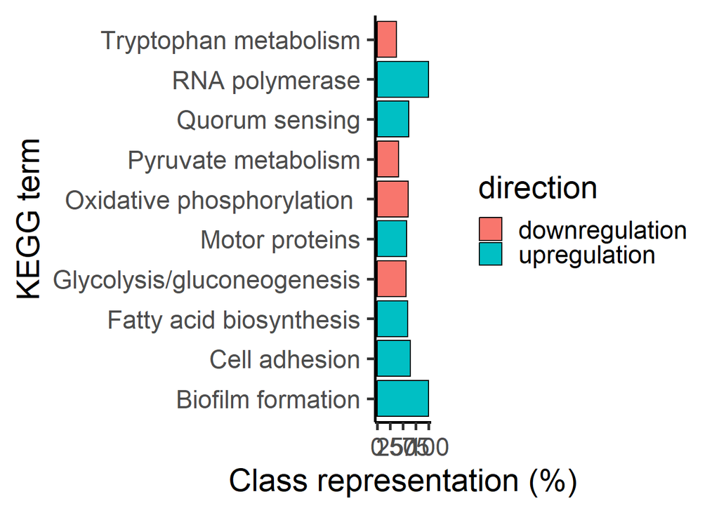

```r
ggplot(data = kegg, aes(x = Class_representation, y = ClassID, fill = direction)) +
geom_bar(stat = "identity", color = "black") +
theme_classic(base_size = 22) +
labs(x = "Class representation (%)", y = "KEGG term")
```

To enhance the visual difference between terms enriched among upregulated and downregulated genes, we could change the class representation values of the terms enriched in downregulated genes to be negative:

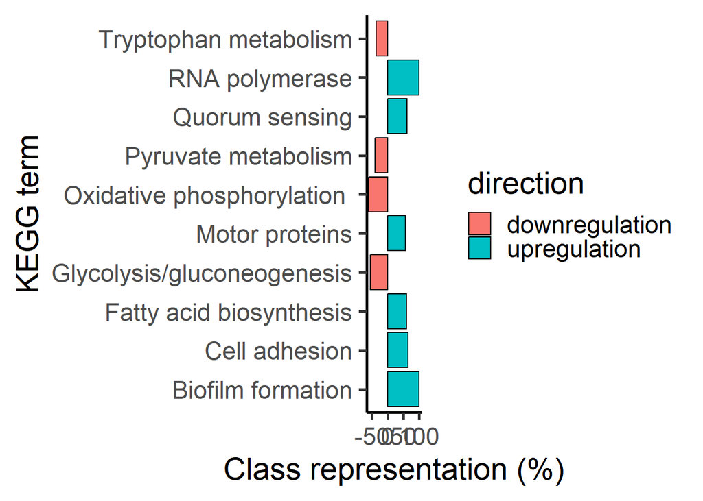

```r
kegg[1:4, "Class_representation"] = -kegg[1:4, "Class_representation"]

ggplot(data = kegg, aes(x = Class_representation, y = ClassID, fill = direction)) +
geom_bar(stat = "identity", color = "black") +
theme_classic(base_size = 22) +
labs(x = "Class representation (%)", y = "KEGG term")
```

A couple of other things to make this graph look nicer: - make the x-axis the same size on the upregulated and downregulated sides (`xlim(-100, 100)`) - adjust the transparency to represent the *p*-values (`alpha = pvalue`) - add a vertical line at x = 0 (`geom_vline(xintercept = 0, linetype = 1, color = "black", linewidth = 0.75)`)

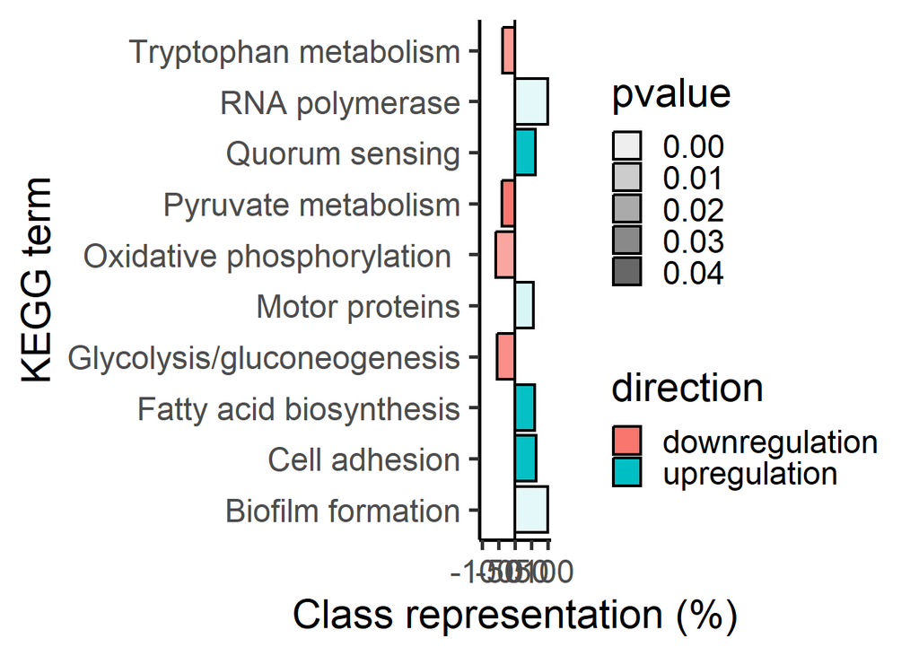

```r
ggplot(data = kegg, aes(x = Class_representation, y = ClassID, fill = direction, alpha = pvalue)) +
geom_bar(stat = "identity", color = "black", linewidth = 0.75) +
theme_classic(base_size = 22) +
labs(x = "Class representation (%)", y = "KEGG term") +
xlim(-100, 100) +
geom_vline(xintercept = 0, linetype = 1, color = "black", linewidth = 0.75)
```

Lastly, Bibakhya asked if I could add a black border (replace `theme_classic` with `theme_bw`) and remove all of the tick marks from both axes for a cleaner look (the lines of code beginning with `theme(panel.grid.major` shown at the bottom here):

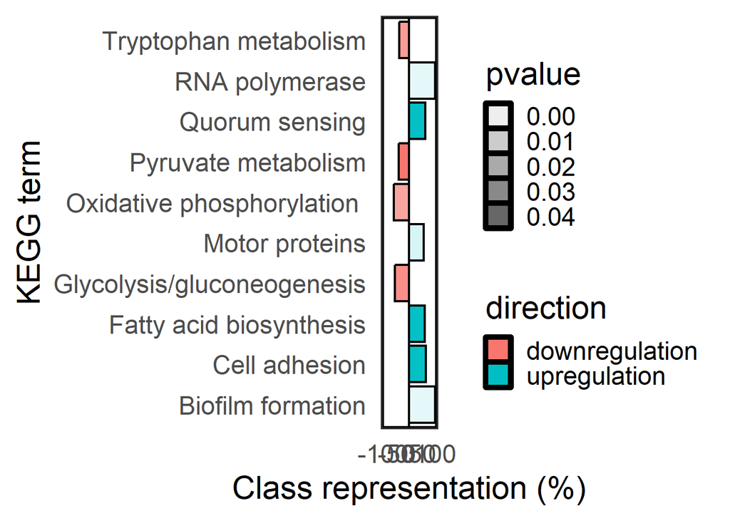

```r
ggplot(data = kegg, aes(x = Class_representation, y = ClassID, fill = direction, alpha = pvalue)) +
geom_bar(stat = "identity", color = "black", linewidth = 0.75) +
theme_bw(base_size = 22) +
labs(x = "Class representation (%)", y = "KEGG term") +
xlim(-100, 100) +
geom_vline(xintercept = 0, linetype = 1, color = "black", linewidth = 0.75) +
theme(panel.grid.major = element_blank(),
        panel.grid.minor = element_blank(),
        panel.background = element_rect(colour = "black", size=2),
         axis.ticks.y=element_blank(),
         axis.ticks.x=element_blank())
```

These are just a few ways you might want to display data from expression analyses. The internet is a great source of inspiration if you’re looking for other ways to display related data.

Several people asked me about how to do a principal component analysis in R using their expression data. This is beyond the scope of this tutorial, but there are instructions online (e.g., [here](https://www.datacamp.com/tutorial/pca-analysis-r)), and Tess and I can help if you have specific questions.